# Part II - Ford go bike data analysis presentation.

## by Beryl Chebet

## Investigation Overview

The overall goal of this project was to perform data analysis mainly focusing on data visualization techniques in the data analysis process. The project is divided into 2 parts :

```
 - The Part 1  is about performing exploratory data visualization  using python visualizaton      libraries to explore the dataset starting from plot of single variables building up to plots of  multiple varibles.
 - Part 2  is  a presentation about the main relationships,trends,and properties from the part 1 of the dataset.
```

## Dataset Overview

The dataset used was the Fordgo bikesystem data which includes information about individual rides made in a bike sharing system covering the greater San Fransisco Bay area. I cleaned the dataset and used a few of the variables for visualizations. The variables used in the data analysis are:

- Duration.
- User type.
- Start hour.
- Start day.

```
'0.11.2'
```

# Key Insights using visualizations

## Number of rides per user type.

> The user type is mostly a subscriber, meaning they pay a fee to use the biking service.

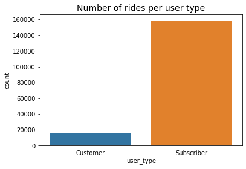

## Duration of rides per user type.

- Subscribers generally take shorter trips, which majority of the rides lasting for 4 minutes and 6 minutes,
- Subscribers and customers histograms are both right skewed,meaning the number of reduce as the duration for the rides increases.

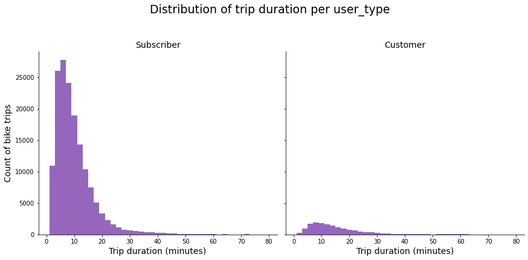

## User type and days of week.

- Without grouping by the user type,Thursdays and Tuesdays had the highest bikerides, while Saturdays and Sundays had the least bike rides.
- If the user and duration is considered ,Duration of Trips on Weekends take longer than those during weekdays for Customers,with the highest duration being on a Sunday 27.78 minutes.
- Subscribers take shorter trips compared to Customers on all days of the week.

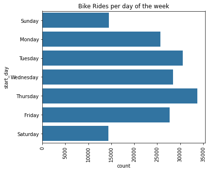

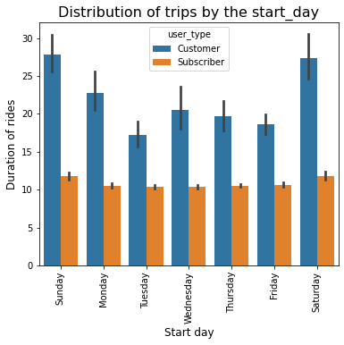

## How the hourly usage varies during a week for Customers and Subscribers

### Customer

Customers have greater numbe rides on Thursdays, at 5pm,6pm and on Fridays, Thursday and Tuesday at 8am.

Over the wwekends on Saturday and Sunday most of the rides start between 12 pm and 4pm for the customer,

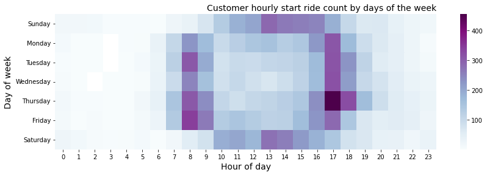

### Subscriber

Majority of subscriber rides take place between 8 and 9 and 17 and 18hrs during the weekdays,

Subscribers take significantly fewer rides during the weekends than during weekdays.

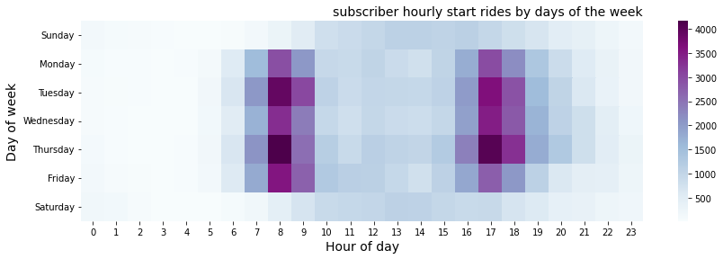